# ToothGrowth Analysis: Full Factorial ANOVA

Len Greski

November 25, 2015

# Background

The course project for *Statistical Inference* within the Johns Hopkins University Data Science curriculum on Coursera includes an analysis of the [ToothGrowth data set](https://stat.ethz.ch/R-manual/R-devel/library/datasets/html/ToothGrowth.html) from the R Datasets package. Students were instructed to use techniques taught in the class (basic hypothesis tests or confidence intervals) to analyze the data. On the course Discussion Forum, students discussed a variety of ways to analyze this data set, and one student asserted that the best way to analyze the ToothGrowth data was as a full factorial analysis of variance, a topic that is not covered in the *Statistical Inference* course.

In response to students’ questions about how the factorial analysis of variance works, I agreed to post a factorial design analysis of variance solution to the problem. During the class, I discovered that Robert Kabacoff uses the ToothGrowth data set for this very purpose in [*R in Action*](https://www.manning.com/books/r-in-action-second-edition). Furthermore, the code for this analysis is available on Kabacoff’s [RiA github repository](https://github.com/kabacoff/RiA2/blob/master/Ch09%20Analysis%20of%20Variance.R), so it is publicly available.

In this report we will discuss the factorial ANOVA model, relating it to concepts taught in the *Statistical Inference* course. Although the bulk of the analysis is based on code from *R in Action* (RiA), we will make adjustments to simplify the analysis, explain concepts that are new to students in *Statistical Inference*, or connect specific *RiA* points to content from the *Statistical Inference* course.

# Executive Summary

In the 1940s, researchers were interested developing bioassays of vitamin C, because the Canadian government had difficulty providing natural sources of the vitamin to their armed forces during most of the year (Crampton, p. 491). Because guinea pigs (like humans) do not metabolize their own vitamin C, the Winter Institute of Anatomy and Biology developed a bioassay of vitamin C by testing it on guinea pigs. Analysis of the ToothGrowth data from Crompton’s 1947 analysis in the *Journal of Nutrition* demonstrates that:

- Increasing dose is associated with higher tooth growth,
- Orange Juice produced more tooth growth than Vitamin C at lower doses (0.5 and 1.0 mg), and
- Both Orange Juice and Vitamin C produced equal tooth growth at a 2.0 mg dose.

Relative to the techniques taught in the *Statistical Inference* course, there are two significant findings:

# Exploratory Data Analysis

Typically, students in the Data Science Specialization are asked to begin each project with an exploratory data analysis. In Kabacoff’s analysis, he begins with a demonstration that the experimental design for the study is a 2x3 factorial model: two levels of supplement type (`supp`), and three levels of dosage (`dose`).

```r
attach(ToothGrowth)
kable(table(supp,dose))
```

|  | 0.5 | 1 | 2 |
| --- | --- | --- | --- |
| OJ | 10 | 10 | 10 |
| VC | 10 | 10 | 10 |

Because the number of guinea pigs in each of the six cells of the experimental design is equivalent, this design qualifies as a “balanced” design. When a design is unbalanced, changing the order of effects in the analysis can change the results. The balanced design alleviates the need for us to manage the order of the effects specifications in the analysis of variance.

Next, Kabacoff reports the means and standard deviations for each cell in the design. Note that the code here is slightly modified from Kabacoff’s version, so we can print both the means and standard deviations in a single table.

### Figure 1: Means and Standard Deviations by Supplement / Dosage Combination

```r
theMeans <- aggregate(len, by=list(supp,dose), FUN=mean)
names(theMeans)[names(theMeans) == "x"] <- "Mean"
theSDs <- aggregate(len, by=list(supp,dose), FUN=sd)
StdDev <- theSDs$x
kable(cbind(theMeans,StdDev))
```

| Group.1 | Group.2 | Mean | StdDev |
| --- | --- | --- | --- |
| OJ | 0.5 | 13.23 | 4.459708 |
| VC | 0.5 | 7.98 | 2.746634 |
| OJ | 1 | 22.70 | 3.910953 |
| VC | 1 | 16.77 | 2.515309 |
| OJ | 2 | 26.06 | 2.655058 |
| VC | 2 | 26.14 | 4.797731 |

To provide a more visual representation of the two main effects, we include boxplots for `dose` and `supp`. Note that these were not included in Kabacoff’s original analysis.

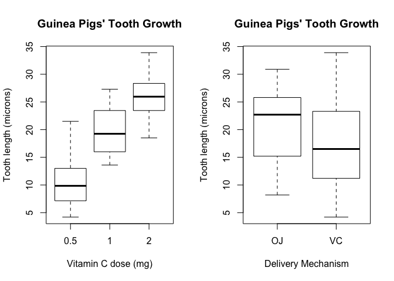

```r
par(mfrow=c(1,2))
boxplot(len ~ dose,data=ToothGrowth,
     xlab="Vitamin C dose (mg)",
     ylab="Tooth length (microns)",
     main="Guinea Pigs' Tooth Growth")
boxplot(len ~ supp,data=ToothGrowth,
     xlab="Delivery Mechanism",
     ylab="Tooth length (microns)",
      main="Guinea Pigs' Tooth Growth")
```

Given the techniques that were taught in the *Statistical Inference* course, the next step in this analysis would be to establish a set of null and alternate hypotheses to test, or to generate confidence intervals for some subset of factors and compare them. Both the number and nature of tests to be conducted (e.g. one-tailed versus two-tailed, tests on an individual independent variable versus combination of the two independent variables, etc.) are left to the student’s discretion.

Kabacoff’s analysis includes an interaction plot that highlights the 95% confidence intervals across supplement type and dosage levels. We include it here because it summarises all the potential tests to be conducted in a single chart. The plot illustrates that at dosages of 0.5 and 1.0 mg of ascorbic acid, Orange Juice is associated with higher tooth growth because the confidence intervals do not overlap. At dosage of 2.0 mg, however, tooth growth does not vary significantly by supplement type. The plot also demonstrates that increases in dosage are associated with increases in tooth growth, as the two lines that connect the dosage levels within a supplement type are [monotonically increasing](https://en.wikipedia.org/wiki/Monotonic_function) (1).

### Figure 2: Tooth Growth by Supplement Type and Dosage

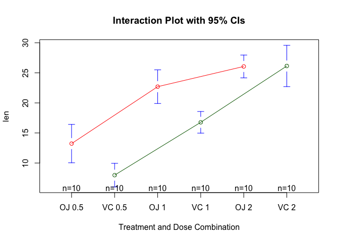

```r
library(gplots)
plotmeans(len ~ interaction(supp, dose, sep=" "),
          connect=list(c(1, 3, 5),c(2, 4, 6)),
          col=c("red","darkgreen"),
          main = "Interaction Plot with 95% CIs",
          xlab="Treatment and Dose Combination")
```

Note that the confidence intervals in the preceding chart do not account for the fact that we are conducting multiple comparisons of means. The process of multiple comparisons among means increases our likelihood of a type 1 error: rejecting a null hypothesis when it is in fact true. Since we have 6 means in the study, we can make up to $\binom {6}{2} = 15$ comparisons of means, and the probability of at least one type 1 error among 15 comparisons is 0.537, or almost 54% [(2)](https://en.wikipedia.org/wiki/Multiple_comparisons_problem). Due to the multiple comparisons problem, analysis of variance is preferred over multiple difference of means t-tests for analyzing this data.

# Analysis of Variance

Given the importance of analysis of variance (ANOVA) models across numerous disciplines in the natural and social science, *R in Action* devotes an entire chapter to different flavors of ANOVA models, including:

- One-way ANOVA,
- One-way Analysis of Covariance (ANCOVA),
- Two-way factorial ANOVA,
- Repeated measures ANOVA, and
- Multivariate Analysis of Variance (MANOVA).

Analysis of Variance is particularly well suited for analyses that are organized with an experimental design: placing subjects randomly into specific categories of test and control groups to test the effectiveness of one or more types of a “test” treatment versus one or more control groups. For a more detailed explanation of the various ANOVA models, the reader is referred to *R in Action*, pp. 212 - 238.

As stated earlier, the ToothGrowth data set is used to illustrate the concepts of two-way factorial ANOVA, where the dependent variable is assessed across groups formed by the combination of two factor variables, `dose` and `supp`. There are two major benefits of the analysis of variance over paired comparisons of means via t-tests, including:

- ANOVA tests the overall equality across means to control the Type 1 error rate, and
- ANOVA provides capabilities to test subgroups beyond simple pairwise comparisons of means, while simultaneously controlling the Type 1 error rate.

The basic analysis of variance output from R includes an F-test that tests the following hypothesis:

$H_{null}: \mu_1 = \mu_2 = \mu_3 = \mu_4 = \mu_5 = \mu_6$ $H_{alt}: \mu_1 \neq \mu_2 \neq \mu_3 \neq \mu_4 \neq \mu_5 \neq \mu_6$

Since F is the ratio of between groups variance to within groups variance [(3)](https://en.wikipedia.org/wiki/F-test), an F value of 1.0 represents the null hypothesis: all means are equal. When F is large enough to exceed a critical value given the number of groups and degrees of freedom, we reject the null hypothesis and conclude that there is at least one difference between the group means.

Isolating where the differences are across the different groups requires post hoc comparisons of means, such as [Tukey’s Honest Significant Difference, or HSD](https://en.wikipedia.org/wiki/Tukey%27s_range_test) test.

We will begin our analysis by reviewing the one way main effects for `supp` and `dose` to illustrate how the results change as model terms are added.

```r
fit <- aov(len ~ supp )
summary(fit)
```

```
##             Df Sum Sq Mean Sq F value Pr(>F)
## supp         1    205  205.35   3.668 0.0604 .
## Residuals   58   3247   55.98
## ---
## Signif. codes:  0 '***' 0.001 '**' 0.01 '*' 0.05 '.' 0.1 ' ' 1
```

The F value for the one way ANOVA of `len` by `supp` is 3.668, with 1,58 degrees of freedom. Since the probability value of the F-test is 0.0604, we fail to reject the null hypothesis that $\mu_1 = \mu_2$ at $\alpha = 0.05$. By itself, supplement type (OJ vs. VC) appears to have no significant impact on tooth length.

```r
fit <- aov(len ~ dose)
summary(fit)
```

```
##             Df Sum Sq Mean Sq F value   Pr(>F)
## dose         2   2426    1213   67.42 9.53e-16 ***
## Residuals   57   1026      18
## ---
## Signif. codes:  0 '***' 0.001 '**' 0.01 '*' 0.05 '.' 0.1 ' ' 1
```

Substantively the test result means that differences in dosage are associated with different levels of tooth growth. We would need to conduct post hoc tests to quantify the effects more specifically, such as “larger doses are associated with increased tooth growth.”

Finally, we report the two-way factorial ANOVA test along with the model coefficients, as presented in *R in Action*. When given a model forumla specified as an interaction effect, the `aov()` function automatically includes the relevant main effects in the model.

```r
fit <- aov(len ~ supp * dose)
summary(fit)
```

```
##             Df Sum Sq Mean Sq F value   Pr(>F)
## supp         1  205.4   205.4  15.572 0.000231 ***
## dose         2 2426.4  1213.2  92.000  < 2e-16 ***
## supp:dose    2  108.3    54.2   4.107 0.021860 *
## Residuals   54  712.1    13.2
## ---
## Signif. codes:  0 '***' 0.001 '**' 0.01 '*' 0.05 '.' 0.1 ' ' 1
```

Also, we notice that after accounting for the other effects, the `supp` effect is now significantly different from zero. That is, by controlling for the level of dosage and the interaction effect `dose * supp`, we see that there is a significant, independent effect for supplement type (p < 0.001).

Looking at the specific model coefficients, we observe that they are reported as changes relative to a base group, listed as the intercept. The intercept is simply the cell with the lowest factor levels as defined with the `as.factor()` function.

```r
fit$coefficients
```

```
##  (Intercept)       suppVC        dose1        dose2 suppVC:dose1
##        13.23        -5.25         9.47        12.83        -0.68
## suppVC:dose2
##         5.33
```

In the ToothGrowth data, the intercept represents the OJ / Dose 0.5 cell. We can rebuild our original table of means by using the coefficients as follows, adding the relevant effects to arrive at the cell means.

```r
Supplement <- c("OJ", "VC", "OJ", "VC", "OJ", "VC")
Dosage <- c("0.5","0.5","1.0","1.0","2.0","2.0")
Mean <- c(13.23,
          13.23 - 5.25,
          13.23 + 9.47,
          13.23 + 9.47  - 5.25 - 0.68,
          13.23 + 12.83,
          13.23 + 12.83 - 5.25 + 5.33)
kable(data.frame(Supplement,Dosage,Mean))
```

| Supplement | Dosage | Mean |
| --- | --- | --- |
| OJ | 0.5 | 13.23 |
| VC | 0.5 | 7.98 |
| OJ | 1.0 | 22.70 |
| VC | 1.0 | 16.77 |
| OJ | 2.0 | 26.06 |
| VC | 2.0 | 26.14 |

Note that the results match those we produced by aggregating the data earlier in the analysis.

The entire analysis may be presented visually with the `interaction2wt()` plot that Kabacoff used in closing to summarize the analysis.

```r
interaction2wt(len ~ supp * dose,
     main="Tooth Length: main effects & 2-way interactions")
```

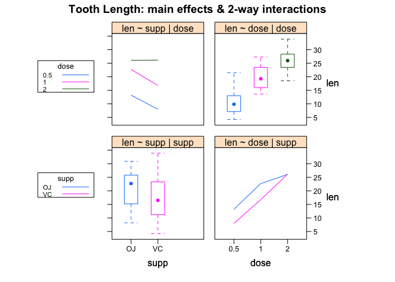

# Conclusions

# Footnotes

[(1)](https://en.wikipedia.org/wiki/Monotonic_function) *Monotonic Function*, Wikipedia, retrieved November 26, 2015.

[(2)](https://en.wikipedia.org/wiki/Multiple_comparisons_problem) *Multiple Comparisons Problem*, Wikipedia, retrieved November 25, 2015.

[(3)](https://en.wikipedia.org/wiki/F-test) *F-test*, Wikipedia, retrieved November 25, 2015.

[(4)](http://stats.stackexchange.com/questions/73869/suppression-effect-in-regression-definition-and-visual-explanation-depiction) *Suppression Effect in Regression*, Cross Validated Stack Exchange Website, retrieved November 25, 2015.

### References

Crampton, E. W. (1947) The growth of the odontoblast of the incisor teeth as a criterion of vitamin C intake of the guinea pig. [*The Journal of Nutrition*](http://jn.nutrition.org/content/33/5/491.full.pdf) 33(5): 491 - 104.

Kabacoff, Robert (2015) – *R in Action: Data analysis and graphics with R, Second Edition,* Manning Publications Co., Shelter Island, New York.